# Introducción Texto como Datos

#### Pre-requisitos:

Vamos a necesitar los siguientes paquetes de R

```r
library(tidyverse)
library(dslabs)
library(textclean)
library(tm)
library(wordcloud)
```

#### Proceso de análisis de texto

1. seleccionar textos: corpus
2. definir los documentos: la unidad de análisis (tweets, oraciones, párrafos, guiones)
3. definir las características: tokens, frases, segmentos, lenguaje, etc
4. convertir estas características a vectores
5. proceso cuantitativo o estadístico para extraer información de las catacterísticas
6. resumen, datos nuevos, etc

En este documento nos enfocaremos en el punto 3 y como limpiar estas características antes de convertirlas a vectores. En particular llevaremos a cabo un topic classification de tweets de Trump. Nos interesa saber de que esta hablando Trump en Twitter. Con esto en mente escogeremos las características y la forma de pre procesar los tweets. En este caso en particular definimos como el corpus todos los tweets de Trump entre 2009 y 2017 (antes de que fuera presidente). Los documentos serán cada uno de los tweets.

#### Cargar y explorar los datos

La libraria `dsblabs` cuenta con una base de datos pre cargada con todos los tweets de la cuenta de Donald Trump entre 2009 y 2017. Para poder utilizarlos solo necesitamos cargar el paquete.

```r
dim(trump_tweets)
```

```
## [1] 20761     8
```

```r
names(trump_tweets)
```

```
## [1] "source"                  "id_str"
## [3] "text"                    "created_at"
## [5] "retweet_count"           "in_reply_to_user_id_str"
## [7] "favorite_count"          "is_retweet"
```

La base cuenta con 20761 tweets distintos y 8 variables. Las variables describen características básicas de los tweets como cuando fueron creados, que tanto interactuo la gente con ellos (favs,retweets, etc).

Exploremos un poco mas como se ven las primeras 3 observaciones de esta base

```r
trump_tweets %>% head(3)
```

```
##               source     id_str
## 1 Twitter Web Client 6971079756
## 2 Twitter Web Client 6312794445
## 3 Twitter Web Client 6090839867
##                                                                                                                                         text
## 1       From Donald Trump: Wishing everyone a wonderful holiday & a happy, healthy, prosperous New Year. Let’s think like champions in 2010!
## 2 Trump International Tower in Chicago ranked 6th tallest building in world by Council on Tall Buildings & Urban Habitat http://bit.ly/sqvQq
## 3                                                                             Wishing you and yours a very Happy and Bountiful Thanksgiving!
##            created_at retweet_count in_reply_to_user_id_str favorite_count
## 1 2009-12-23 12:38:18            28                    <NA>             12
## 2 2009-12-03 14:39:09            33                    <NA>              6
## 3 2009-11-26 14:55:38            13                    <NA>             11
##   is_retweet
## 1      FALSE
## 2      FALSE
## 3      FALSE
```

#### Pre procesamiento de los tweets

Vamos a empezar a limpiar nuestros tweets. Lo primero que haremos será eliminar puntuación, urls, hashtags, etc. Para poder hacer esto vamos a usar las expresiones regulares (regex)

##### Regex

Una expresión regular es un patrón que describe un conjunto específico de cadenas de texto que poseen una estructura en común, son usadas para buscar coincidencias o para remplazarlas. En R podemos usar la libraría `stringr`, este paquete esta incluido en la librería que cargamos al principio conocida como `tidyverse`. `gsub()` es una función en base R (no necesita ningún paquete para usarla) en general las funciones dentro de `stringr` van a ser un poco más rápidas.

Veamos algunos ejemplos de lo que podemos hacer con `stringr`

```r
# Extaer una palabra especīfica de un tweet
str_extract(trump_tweets$text[1], "happy")
```

```
## [1] "happy"
```

```r
str_extract(trump_tweets$text[1], "sad")
```

```
## [1] NA
```

```r
# Si queremos reemplazar todas las a minusculas a mayusculas
str_replace_all(trump_tweets$text[1], "a","A")
```

```
## [1] "From DonAld Trump: Wishing everyone A wonderful holidAy & A hAppy, heAlthy, prosperous New YeAr. Let’s think like chAmpions in 2010!"
```

```r
# equivalente a usar gsub
gsub("a","A",trump_tweets$text[1])
```

```
## [1] "From DonAld Trump: Wishing everyone A wonderful holidAy & A hAppy, heAlthy, prosperous New YeAr. Let’s think like chAmpions in 2010!"
```

```r
## reemplazar todos los números por X's
str_replace_all(trump_tweets$text[1],"[:digit:]","X")
```

```
## [1] "From Donald Trump: Wishing everyone a wonderful holiday & a happy, healthy, prosperous New Year. Let’s think like champions in XXXX!"
```

```r
## reemplazar todas las mayusculas por un 1
str_replace_all(trump_tweets$text[1],"[:upper:]","1")
```

```
## [1] "1rom 1onald 1rump: 1ishing everyone a wonderful holiday & a happy, healthy, prosperous 1ew 1ear. 1et’s think like champions in 2010!"
```

Las expresiones regulares nos van a ayudar a remover cosas como los urls, los hashtags y la puntuación.

Expresión regular para quitar urls

```r
str_replace_all(trump_tweets$text[2],"http[[:alnum:][:punct:]]*"," ")
```

```
## [1] "Trump International Tower in Chicago ranked 6th tallest building in world by Council on Tall Buildings & Urban Habitat  "
```

```r
#funciona igual con gsub
gsub("http[[:alnum:][:punct:]]*"," ",trump_tweets$text[2])
```

```
## [1] "Trump International Tower in Chicago ranked 6th tallest building in world by Council on Tall Buildings & Urban Habitat  "
```

Expresiones regulares para remover usernames y hashtags.

```r
# Quitar usernames
trump_tweets$text[500]
```

```
## [1] "My thoughts on Gadhafi's death, @BarackObama, and the misery index... http://t.co/hgarmpIE #trumpvlog"
```

```r
str_replace_all(trump_tweets$text[500],"@[[:alnum:][:punct:]]*"," ")
```

```
## [1] "My thoughts on Gadhafi's death,   and the misery index... http://t.co/hgarmpIE #trumpvlog"
```

```r
#Quitar hashtags
trump_tweets$text[600]
```

```
## [1] "OPEC is ripping us off on oil. We are ripping ourselves off by investing in unproven green energy. #Solyndra"
```

```r
str_replace_all(trump_tweets$text[600],"#[[:alnum:][:punct:]]*"," ")
```

```
## [1] "OPEC is ripping us off on oil. We are ripping ourselves off by investing in unproven green energy.  "
```

##### Normalización del texto

###### Transformar símbolos a palabras

Los tweets están en ingles así que antes de eliminar toda la puntuación es conveniente hacernos cargo de palabras compuestas, emojis, emoticons, etc. La librería [textclean](https://cran.r-project.org/web/packages/textclean/readme/README.html) ofrece funciones útiles para limpiar texto en ingles que usaremos aquí. En particular nos van a ayudar a sustituir abreviaciones, contracciones, emojis, etc. Existen muchos paquetes que hacen esto en ingles, en español no tanto así que hay que escribir muchas de estas cosas a mano.

```r
x <- "Check it out what's going on."
replace_contraction(x)
```

```
## [1] "Check it out what is going on."
```

```r
y <- "I owe $41 for food"
replace_symbol(y)
```

```
## [1] "I owe  dollar 41 for food"
```

```r
z <- "My  heart 💔 #FreeBritney"
replace_emoji(z)
```

```
## [1] "My heart broken heart #FreeBritney"
```

```r
w <- "Hi :)"
replace_emoticon(w)
```

```
## [1] "Hi smiley "
```

###### Minúsculas

Convertir el texto a minúsculas

```r
trump_tweets$text[1]
```

```
## [1] "From Donald Trump: Wishing everyone a wonderful holiday & a happy, healthy, prosperous New Year. Let’s think like champions in 2010!"
```

```r
tolower(trump_tweets$text[1])
```

```
## [1] "from donald trump: wishing everyone a wonderful holiday & a happy, healthy, prosperous new year. let’s think like champions in 2010!"
```

###### Puntuación

Remover la puntuación de los tweets usamos otra expresión regular

```r
trump_tweets$text[1]
```

```
## [1] "From Donald Trump: Wishing everyone a wonderful holiday & a happy, healthy, prosperous New Year. Let’s think like champions in 2010!"
```

```r
str_replace_all(trump_tweets$text[1],"[:punct:]"," ")
```

```
## [1] "From Donald Trump  Wishing everyone a wonderful holiday   a happy  healthy  prosperous New Year  Let s think like champions in 2010 "
```

###### Stop Words

Antes de convertir en tokens nuestros tweets removemos las stop words, en este caso en particular es una buena idea porque queremos capturar los tópicos de los tweets. En casos como análisis de sentimiento no siempre es una buena idea quitar estas palabras. Para extraerlas utilizaremos la librería `tm`

```r
trump_tweets$text[1]
```

```
## [1] "From Donald Trump: Wishing everyone a wonderful holiday & a happy, healthy, prosperous New Year. Let’s think like champions in 2010!"
```

```r
r_stops <- removeWords(trump_tweets$text[1], stopwords("en"))
r_stops
```

```
## [1] "From Donald Trump: Wishing everyone  wonderful holiday &  happy, healthy, prosperous New Year. Let’s think like champions  2010!"
```

###### Stemming

Método para reducir una palabra, solo quita el final o el inicio de las palabras por lo que en muchos casos no pueden ser interpretadas como palabras. Sigue un algoritmo definido para reducir las palabras así que en general es más rápido que otras opciones. Uno de los métodos más comunes es el algoritmo de Porter que quita el final de las palabras en ingles. Existen varias librerías en R que llevan a cabo esta operación. Por ahora usaremos la función `stemDocument` de `tm`

```r
stemDocument(r_stops)
```

```
## [1] "From Donald Trump: Wish everyon wonder holiday & happy, healthy, prosper New Year. Let’ think like champion 2010!"
```

###### Lematización

Es otro método para reducir palabras, en lugar de solo cortar la palabra extrae la palabra raíz. A comparación del stemming siempre nos va a regresar palabras que existen y son ortográficamente correctas. Para poder hacer esto busca en diccionarios detallados el lemma asociado a cada una de las palabras por lo que suele ser mucho mas lento que hacer stemming. En este ejemplo usaremos la libraría `textstem` , `tm` también cuanta con un método de lemmatización aplicable a documentos dentro de un corpus.

```r
library(textstem)
vector <- c("run", "ran", "running")
lemmatize_words(vector)
```

```
## [1] "run" "run" "run"
```

##### Aplicar todos los pasos a los tweets

1. Limpieza previa: Visualicemos las palabras más frecuentes para saber si hay que eliminar alguna extra:

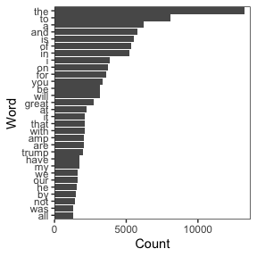

```r
library(qdap)
frecuentes <- freq_terms(trump_tweets$text,30)
plot(frecuentes)
```

```r
detach("package:qdap", unload=TRUE)
```

Antes de definir nuestro corpus en R vamos a llevar a cabo un poco de limpieza. La siguiente función va a remover los urls, usernames, hashtags, lidear con algunos símbolos como ’ y –. Reemplazar contracciones, símbolos, emojis y emoticonos. Al final pasa todas las palabras a minúscula y quita la puntuación.

```r
limpiar<- function(text){
  text <- str_replace_all(text,"http[[:alnum:][:punct:]]*","")
  text <- str_replace_all(text, "@[[:alnum:][:punct:]]*","")
  text <- str_replace_all(text,"#[[:alnum:][:punct:]]*","")
  text <- str_replace_all(text,"–","-")
  text <- str_replace_all(text,"’","'")
  text <- replace_contraction(text)
  text <- replace_emoji(text)
  text <- replace_symbol(text)
  text <- replace_emoticon(text)
  text <- tolower(text)
  text <- str_replace_all(text,"[[:punct:]]","")
  text <- str_replace_all(text, "[^[:alnum:]]", " ")
  text <- str_replace_all(text, '[[:digit:]]+',"")
  text <-removeWords(text,stopwords("en"))
  text <- str_replace_all(text,"trump","")
  text <- stripWhitespace(text)
  text <- str_trim(text)
}

clean_tweets <- trump_tweets %>%
  mutate(text = limpiar(text))
head(clean_tweets$text)
```

```
## [1] "donald wishing everyone wonderful holiday happy healthy prosperous new year let us think like champions"
## [2] "international tower chicago ranked th tallest building world council tall buildings urban habitat"
## [3] "wishing happy bountiful thanksgiving"
## [4] "donald partners tv new reality series entitled omarosas ultimate merger"
## [5] "work begun ahead schedule build greatest golf course history international scotland"
## [6] "donald ivanka jareds wedding spectacular make beautiful couple proud father"
```

Como estamos usando tweets puede que después de quitar los urls, usernames, etc algunos tweets desaparezcan, vamos a eliminarlos antes de seguir.

```r
tweets <- clean_tweets %>% filter(nchar(text) > 1 & !is.na(text))
```

2. Construir el corpus Un corpus es una colección de documentos, la librería `tm` reconoce el corpus como un tipo de objeto `corpus` distinto a los objetos regulares. `tm` cuenta con dos tipos distintos de corpus, la única diferencia entre ellos es si lo vamos a guardar en el disco duro (corpus permanente, PCorpus) o solo en la RAM (volatil o VCorpus). Para construir un objeto VCorpus R necesita interpretar cada elemento (en nuestro caso cada tweet) como un documento. La siguiente función va a generar un Source object.

```r
tweets_source <- VectorSource(tweets$text)
```

Ya que tenemos nuestro Source object es muy fácil generar el corpus. La función VCorpus genera una lista de listas. Cada una de las sublistas tiene el contenido del tweet y metadata asociado al tweet como autor, idioma, etc.

```r
tweets_corpus <- VCorpus(tweets_source)
tweets_corpus[[20]]
```

```
## <<PlainTextDocument>>
## Metadata:  7
## Content:  chars: 61
```

```r
tweets_corpus[[20]][1]
```

```
## $content
## [1] "donald backs apprentice randal pinkett nj lieutenant governor"
```

```r
str(tweets_corpus[[20]])
```

```
## List of 2
##  $ content: chr "donald backs apprentice randal pinkett nj lieutenant governor"
##  $ meta   :List of 7
##   ..$ author       : chr(0)
##   ..$ datetimestamp: POSIXlt[1:1], format: "2021-06-25 05:46:24"
##   ..$ description  : chr(0)
##   ..$ heading      : chr(0)
##   ..$ id           : chr "20"
##   ..$ language     : chr "en"
##   ..$ origin       : chr(0)
##   ..- attr(*, "class")= chr "TextDocumentMeta"
##  - attr(*, "class")= chr [1:2] "PlainTextDocument" "TextDocument"
```

Existe otra opción con la cual podemos incorporar todo lo que sabemos de los tweets a nuestro corpus y esto es usando la función `DataframeSource()`

```r
trump <- as.data.frame(tweets)
#necesitamos este paso extra para que tm lea el documento
trump <- trump %>% rename(doc_id = id_str) %>%
  select(doc_id, text)
df_source <- DataframeSource(trump)
#Construir el corpus
df_corpus <- VCorpus(df_source)
df_corpus
```

```
## <<VCorpus>>
## Metadata:  corpus specific: 0, document level (indexed): 0
## Content:  documents: 20578
```

```r
df_corpus[[1]]
```

```
## <<PlainTextDocument>>
## Metadata:  7
## Content:  chars: 103
```

```r
str(df_corpus[[1]])
```

```
## List of 2
##  $ content: chr "donald wishing everyone wonderful holiday happy healthy prosperous new year let us think like champions"
##  $ meta   :List of 7
##   ..$ author       : chr(0)
##   ..$ datetimestamp: POSIXlt[1:1], format: "2021-06-25 05:46:26"
##   ..$ description  : chr(0)
##   ..$ heading      : chr(0)
##   ..$ id           : chr "6971079756"
##   ..$ language     : chr "en"
##   ..$ origin       : chr(0)
##   ..- attr(*, "class")= chr "TextDocumentMeta"
##  - attr(*, "class")= chr [1:2] "PlainTextDocument" "TextDocument"
```

3. Ya que tenemos nuestro corpus podemos escribir una función para terminar de limpiar todos los tweets. `tm` cuenta una función `tm_map()`. La funciones `map` son comunes en R y nos ayudan a aplicar la misma función a cada uno de los elementos y nos regresa un vector de la misma longitud que los inputs. Esta función nos va a permitir limpiar todos los documentos juntos sin tener que explícitamente iterar sobre ellos.

```r
#Ejemplo general de map:
(df <- tibble(
a = rnorm(3),
b = rnorm(3),
c = rnorm(3),
d = rnorm(3)
))
```

```
## # A tibble: 3 x 4
##        a      b        c     d
##    <dbl>  <dbl>    <dbl> <dbl>
## 1 -0.851  0.625 -0.00479  1.45
## 2  0.914 -0.475  1.92    -1.17
## 3  0.690  0.301  1.04    -1.24
```

```r
df %>% map_dbl(mean)
```

```
##          a          b          c          d
##  0.2508454  0.1503021  0.9843819 -0.3200671
```

Stemming:

```r
clean_corpus <- tm_map(tweets_corpus, stemDocument)
clean_corpus[[1]]$content
```

```
## [1] "donald wish everyon wonder holiday happi healthi prosper new year let us think like champion"
```

Ya con nuestro corpus limpio podemos pasar al siguiente paso que es transformar las características a una matriz de co-ocurrencias

#### Calcular matrices de co-ocurrencias

#### Term-document matrix

Podemos utilizar la función `TermDocumentMatrix` aplicada al corpus limpio. Si no le pasamos ningún parámetro a esta función la matriz va a ser calculada utilizando la frecuencia

```r
tweets_tdm <- TermDocumentMatrix(clean_corpus, list(weighting = weightTfIdf,
                                                    sparse=TRUE))
tweets_tdm
```

```
## <<TermDocumentMatrix (terms: 11170, documents: 20578)>>
## Non-/sparse entries: 177507/229678753
## Sparsity           : 100%
## Maximal term length: 30
## Weighting          : term frequency - inverse document frequency (normalized) (tf-idf)
```

la sparcity de la matriz es demasiada, vamos a explorar un poco que tan frecuentes aparecen las palabras en esta matriz sumando sobre todos los tweets

```r
freq <- rowSums(as.matrix(tweets_tdm))
freq %>% head(5)
```

```
##       aaa     aaron   abandon      abba    abbott
## 12.473640  1.592091 18.482070  3.459046  1.194068
```

```r
freq %>% tail(5)
```

```
##        zucker    zuckerberg zuckerbergget     zuckerman         zuker
##     10.583448      3.858555      1.432882      8.029199      1.194068
```

```r
tweets_tdm<- removeSparseTerms(tweets_tdm, 0.99)
tweets_tdm
```

```
## <<TermDocumentMatrix (terms: 155, documents: 20578)>>
## Non-/sparse entries: 69840/3119750
## Sparsity           : 98%
## Maximal term length: 12
## Weighting          : term frequency - inverse document frequency (normalized) (tf-idf)
```

Podemos ver como se ve nuestra matriz

```r
inspect(tweets_tdm[1:6,1:20])
```

```
## <<TermDocumentMatrix (terms: 6, documents: 20)>>
## Non-/sparse entries: 0/120
## Sparsity           : 100%
## Maximal term length: 8
## Weighting          : term frequency - inverse document frequency (normalized) (tf-idf)
## Sample             :
##           Docs
## Terms      1 2 3 4 5 6 7 8 9 10 11 12 13 14 15 16 17 18 19 20
##   alway    0 0 0 0 0 0 0 0 0  0  0  0  0  0  0  0  0  0  0  0
##   amaz     0 0 0 0 0 0 0 0 0  0  0  0  0  0  0  0  0  0  0  0
##   america  0 0 0 0 0 0 0 0 0  0  0  0  0  0  0  0  0  0  0  0
##   american 0 0 0 0 0 0 0 0 0  0  0  0  0  0  0  0  0  0  0  0
##   amp      0 0 0 0 0 0 0 0 0  0  0  0  0  0  0  0  0  0  0  0
##   anoth    0 0 0 0 0 0 0 0 0  0  0  0  0  0  0  0  0  0  0  0
```

Por último podemos visualizar las palabras más frecuentes con una nube:

```r
findFreqTerms(tweets_tdm, 100) %>% head(25)
```

```
##  [1] "alway"     "amaz"      "america"   "american"  "amp"       "anoth"
##  [7] "apprentic" "attack"    "back"      "bad"       "believ"    "best"
## [13] "better"    "big"       "busi"      "call"      "campaign"  "can"
## [19] "celebr"    "china"     "clinton"   "come"      "congratul" "cont"
## [25] "countri"
```

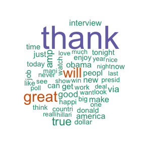

```r
freq <- data.frame(sort(rowSums(as.matrix(tweets_tdm)), decreasing=TRUE))
wordcloud(rownames(freq), freq[,1], max.words=50, colors=brewer.pal(1, "Dark2"))
```